# Introduction-Python-Pandas

## Say hello to Python!

Printing a statement in C++

```
#include<iostream>

using namespace std;

int main()
{
    cout << "Hello World" << endl;
}
```

Printing a statement in Java.

```
public class HelloWorld {
    public static void main(String[] args) {
        System.out.println("Hello, World");
    }

}
```

Not really here to stand a language war!

```python
print('Hello there, Human!')
```

```
Hello there, Human!
```

### Let's do some mathematics!

Remember `(x + y)^2 = x^2 + 2*x*y + y^2`

Let's see if it actually works.

```python
x = 5 # Let's assign values to a variable
y = 2
```

```python
z = x + y
```

```python
type(z)
```

```
int
```

```python
type(x)
```

```
int
```

```python
type(y)
```

```
int
```

```python
# Powers in Python
z**2  # equivalent to writing (x + y)**2
```

```
49
```

```python
x**2 + 2*x*y + y**2
```

```
49
```

### =, == assignments and assert

```python
z**2 == x**2 + 2*x*y + y**2
```

```
True
```

YES!!! It works, we weren't taught the wrong things.

```python
first_name = 'Michael'
last_name = 'Scott'
```

```python
type(first_name), type(last_name)
```

```
(str, str)
```

```python
first_name + last_name
```

```
'MichaelScott'
```

### Exercise

Print out `first_name` and `last_name` with a space in between.

Hint: a space/tab is also represented as a string underneath.

(2 mins)

```python
# %load sols/exercise1.py
```

```python
type(' ')
```

```
str
```

#### Can you multiply integers with strings?

```python
3*first_name
```

```
'MichaelMichaelMichael'
```

```python
3*(first_name + ' ')
```

```
'Michael Michael Michael '
```

```python
import math
```

```python
math.sqrt(100)
```

```
10.0
```

```python
result = math.sqrt(100)
```

```python
type(result)
```

```
float
```

### Containers in Python

```python
project_1 = 1000
project_2 = 1500
project_3 = 400
```

```python
# Lists
projects = [1000, 1500, 400]
```

```python
projects
```

```
[1000, 1500, 400]
```

```python
projects[0]
```

```
1000
```

```python
projects[2]
```

```
400
```

```python
# Dictionary
dictionary_of_capitals = {
    'Belgium': 'Brussels',
    'Netherlands': 'Amsterdam',
    'France': 'Paris'
}
```

```python
dictionary_of_capitals = {'Belgium': 'Brussels', 'Netherlands': 'Amsterdam','France': 'Paris'}
```

```python
dictionary_of_capitals
```

```
{'Belgium': 'Brussels', 'Netherlands': 'Amsterdam', 'France': 'Paris'}
```

```python
dictionary_of_capitals['Belgium']
```

```
'Brussels'
```

```python
code_break = {'a': 1, 'b': 2, 'c': 3, 'd': 4}
```

```python
code_break['c']
```

```
3
```

### Let's write some functions

A function is exactly what is sounds like in python.

It takes in values and spits out results.

It can be defined as `f(x) = y`.

#### Let's write a squaring function, which returns the square of a number

```python
def f(x):
    result = x**2
    return result
```

```python
f(4)
```

```
16
```

```python
def square(input_value):
    return input_value**2
```

```python
square(4)
```

```
16
```

```python
def padding(input_string):
    padded_string = '!!! ' + input_string + ' !!!'
    return padded_string
```

```python
padding('Nine Nine')
```

```
'!!! Nine Nine !!!'
```

```python
padding(first_name)
```

```
'!!! Michael !!!'
```

```python
# 1 + 'python'
```

### Exercise

Write a function which takes in country and returns the capital using the capital dictionary.

(3 mins)

```python
# %load sols/exercise2.py
```

```python
# find_capital('Belgium')
```

```python
# find_capital('Netherlands')
```

```python
# find_capital('Germany')
```

## What `if` I do that? or else or elif

```python
# Check a number is even.

number = 10
```

```python
number%2
```

```
0
```

```python
remainder = number%2
```

```python
remainder == 0
```

```
True
```

```python
10 % 2
```

```
0
```

```python
if 10 % 2 == 0:
    print('yes its even')
```

```
yes its even
```

```python
number = 3
```

```python
if number % 2 == 0:
    print("It's even")
```

```python
if number % 2 == 0:
    print("It's even")
else:
    print("It's odd")
```

```
It's odd
```

```python
def divisible_by(number):
    if number % 2 == 0:
        return 'divisible by 2'
    elif number % 3 == 0:
        return 'divisible by 3'
    elif number % 5 == 0:
        return 'divisible by 5'
    else:
        return 'not divisible by 2, 3 and 5'
```

```python
divisible_by(2)
```

```
'divisible by 2'
```

```python
divisible_by(3)
```

```
'divisible by 3'
```

```python
divisible_by(5)
```

```
'divisible by 5'
```

```python
divisible_by(7)
```

```
'not divisible by 2, 3 and 5'
```

## `for` loops loops and loops

What if you want to iterate through a list of number?

```python
print(square(1))
print(square(2))
print(square(3))
print(square(4))
print(square(5))
```

```
1
4
9
16
25
```

```python
for number in [1, 2, 3, 4, 5]:
    print(square(number))
```

```
1
4
9
16
25
```

```python
def fizzbuzz(number):
    for i in range(1, number + 1):
        if i % 15 == 0:
            print('fizzbuzz')
        elif i % 3 == 0:
            print('fizz')
        elif i % 5 == 0:
            print('buzz')
        else:
            print(i)
```

```python
fizzbuzz(20)
```

```
1
2
fizz
4
buzz
fizz
7
8
fizz
buzz
11
fizz
13
14
fizzbuzz
16
17
fizz
19
buzz
```

## Let's talk about Pandas now

```python
import pandas as pd
```

### DataFrame the building blocks

Pretty much an excel sheet, but much much more powerful

```python
import random
```

```python
maths_score = [random.randint(40, 100) for i in range(10)]
```

```python
physics_score = [random.randint(40, 100) for i in range(10)]
```

```python
english_score = [random.randint(40, 100) for i in range(10)]
```

```python
df = pd.DataFrame({'maths': maths_score, 'physics': physics_score, 'english': english_score})
```

```python
df
```

|  | maths | physics | english |
| --- | --- | --- | --- |
| 0 | 93 | 42 | 76 |
| 1 | 98 | 97 | 60 |
| 2 | 87 | 82 | 99 |
| 3 | 87 | 95 | 92 |
| 4 | 82 | 59 | 74 |
| 5 | 91 | 91 | 55 |
| 6 | 46 | 98 | 79 |
| 7 | 57 | 77 | 45 |
| 8 | 82 | 82 | 89 |
| 9 | 43 | 54 | 88 |

```python
df.mean()
```

```
maths      76.6
physics    77.7
english    75.7
dtype: float64
```

```python
df.describe()
```

|  | maths | physics | english |
| --- | --- | --- | --- |
| count | 10.00000 | 10.000000 | 10.000000 |
| mean | 76.60000 | 77.700000 | 75.700000 |
| std | 20.16157 | 19.675422 | 17.537579 |
| min | 43.00000 | 42.000000 | 45.000000 |
| 25% | 63.25000 | 63.500000 | 63.500000 |
| 50% | 84.50000 | 82.000000 | 77.500000 |
| 75% | 90.00000 | 94.000000 | 88.750000 |
| max | 98.00000 | 98.000000 | 99.000000 |

```python
df.mean(axis=1)
```

```
0    70.333333
1    85.000000
2    89.333333
3    91.333333
4    71.666667
5    79.000000
6    74.333333
7    59.666667
8    84.333333
9    61.666667
dtype: float64
```

```python
df['maths']
```

```
0    93
1    98
2    87
3    87
4    82
5    91
6    46
7    57
8    82
9    43
Name: maths, dtype: int64
```

```python
df['maths'].hist()
```

[output not shown]

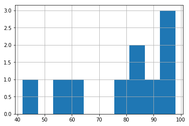

```python
df['physics'].hist()
```

```python
maths_score = [random.randint(40, 100) for i in range(1000)]
physics_score = [random.randint(40, 100) for i in range(1000)]
df = pd.DataFrame({'maths': maths_score, 'physics': physics_score})
```

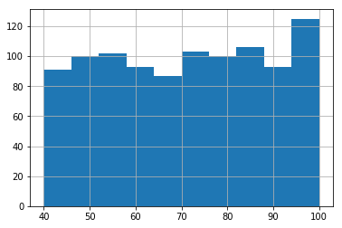

```python
df['maths'].hist()
```

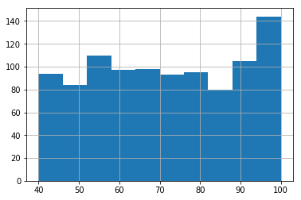

```python
df['physics'].hist()
```

```python
import numpy as np
```

```python
ts = pd.Series(np.random.randn(1000), index=pd.date_range('1/1/2000', periods=1000))
```

```python
ts.head(5)
```

```
2000-01-01   -0.092102
2000-01-02   -0.163245
2000-01-03    0.385769
2000-01-04   -2.327827
2000-01-05    0.090118
Freq: D, dtype: float64
```

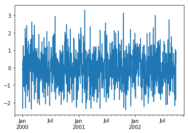

```python
ts.plot()
```

```python
ts = ts.cumsum()
```

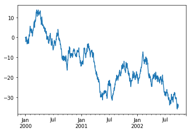

```python
ts.plot()
```

```python
# Let's suppose there are 4 stocks A, B, C and D and we generate random normal distributed datapoints.
df = pd.DataFrame(np.random.randn(1000, 4), index=ts.index, columns=list('ABCD'))
```

```python
df = df.cumsum()
```

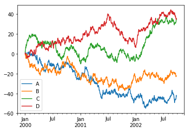

```python
df.plot()
```

```python
# So what happened on the 5th day
df.iloc[5]
```

```
A    0.576242
B   -4.300914
C    5.844391
D    0.025208
Name: 2000-01-06 00:00:00, dtype: float64
```

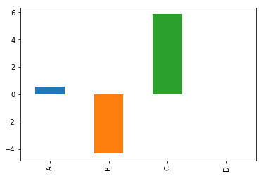

```python
df.iloc[5].plot(kind='bar')
```

```python
df.iloc[5:10]
```

|  | A | B | C | D |
| --- | --- | --- | --- | --- |
| 2000-01-06 | 0.576242 | -4.300914 | 5.844391 | 0.025208 |
| 2000-01-07 | 0.853065 | -4.728019 | 7.775746 | -1.283193 |
| 2000-01-08 | 1.071421 | -3.459759 | 9.387660 | -1.443585 |
| 2000-01-09 | 0.584170 | -4.932278 | 8.351560 | -1.979376 |
| 2000-01-10 | -0.068425 | -4.712175 | 7.772226 | -2.430454 |

```python
df.iloc[5:100].sum()
```

```
A    -207.844894
B   -1129.223752
C    1437.679430
D     225.629216
dtype: float64
```

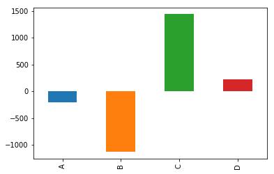

```python
df.iloc[5:100].sum().plot(kind='bar')
```

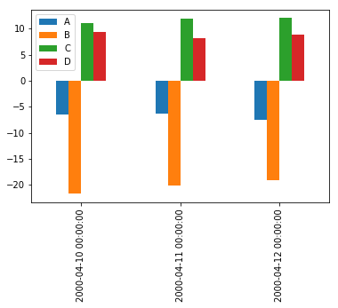

```python
df.iloc[100:103].plot(kind='bar')
```

```python
df = pd.DataFrame({'a': np.random.randn(1000) + 1, 'b': np.random.randn(1000), 'c': np.random.randn(1000) - 1}, columns=['a', 'b', 'c'])
```

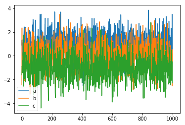

```python
df.plot()
```

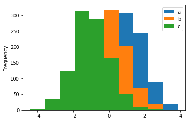

```python
df.plot.hist()
```

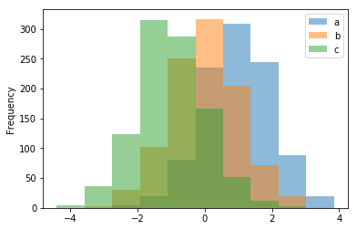

```python
df.plot.hist(alpha=0.5)
```

```python
df = pd.DataFrame(np.random.rand(10, 5), columns=['A', 'B', 'C', 'D', 'E'])
```

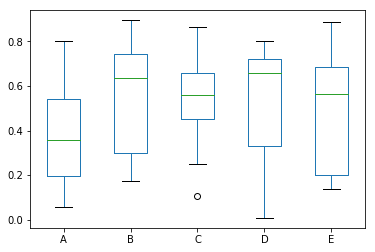

```python
df.plot.box()
```

```python
df
```

|  | A | B | C | D | E |
| --- | --- | --- | --- | --- | --- |
| 0 | 0.056147 | 0.881687 | 0.442692 | 0.429745 | 0.634799 |
| 1 | 0.313761 | 0.586821 | 0.106400 | 0.711281 | 0.197256 |
| 2 | 0.141262 | 0.295168 | 0.838759 | 0.097578 | 0.212123 |
| 3 | 0.785715 | 0.894286 | 0.662050 | 0.008157 | 0.691439 |
| 4 | 0.398935 | 0.199869 | 0.469417 | 0.607906 | 0.144059 |
| 5 | 0.446399 | 0.717343 | 0.577355 | 0.295813 | 0.489343 |
| 6 | 0.249343 | 0.751317 | 0.536578 | 0.803427 | 0.673332 |
| 7 | 0.570926 | 0.681053 | 0.862677 | 0.722241 | 0.137220 |
| 8 | 0.177045 | 0.174633 | 0.248402 | 0.750153 | 0.877885 |
| 9 | 0.803114 | 0.303586 | 0.645640 | 0.718586 | 0.887793 |

```python
df = pd.DataFrame(np.random.rand(50, 2), columns=['lat', 'long'])
```

```python
df.head()
```

|  | lat | long |
| --- | --- | --- |
| 0 | 0.068605 | 0.866981 |
| 1 | 0.839670 | 0.829968 |
| 2 | 0.670976 | 0.795974 |
| 3 | 0.778817 | 0.043264 |
| 4 | 0.720097 | 0.523886 |

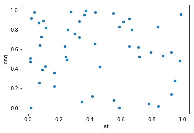

```python
df.plot.scatter(x='lat', y='long')
```

Pandas is a powerful tool, you can do *a lot* with it. For some more visualisations checkout https://pandas.pydata.org/pandas-docs/stable/visualization.html

## Enough with random data points, let's work with some real datasets

```python
# This dataset is a dump from FAA, USA
flights_in_US = pd.read_csv('data/data/passengers.csv',index_col=0)
```

```python
flights_in_US.head()
```

|  | YEAR | ORIGIN | DEST | UNIQUE_CARRIER_NAME | PASSENGERS |
| --- | --- | --- | --- | --- | --- |
| 0 | 1990 | ABE | ACY | {'US Airways Inc.'} | 73.0 |
| 1 | 1990 | ABE | ATL | {'Eastern Air Lines Inc.'} | 73172.0 |
| 2 | 1990 | ABE | AVL | {'Westair Airlines Inc.'} | 0.0 |
| 3 | 1990 | ABE | AVP | {'Westair Airlines Inc.', 'US Airways Inc.', '... | 8397.0 |
| 4 | 1990 | ABE | BHM | {'Eastern Air Lines Inc.'} | 59.0 |

```python
# This dataset is from http://www.partow.net/miscellaneous/airportdatabase/
lat_long = pd.read_csv('data/data/GlobalAirportDatabase.txt', delimiter=':', header=None)
```

```python
lat_long.head()
```

|  | 0 | 1 | 2 | 3 | 4 | 5 | 6 | 7 | 8 | 9 | 10 | 11 | 12 | 13 | 14 | 15 |
| --- | --- | --- | --- | --- | --- | --- | --- | --- | --- | --- | --- | --- | --- | --- | --- | --- |
| 0 | AYGA | GKA | GOROKA | GOROKA | PAPUA NEW GUINEA | 6 | 4 | 54 | S | 145 | 23 | 30 | E | 1610 | -6.082 | 145.392 |
| 1 | AYLA | LAE | NaN | LAE | PAPUA NEW GUINEA | 0 | 0 | 0 | U | 0 | 0 | 0 | U | 0 | 0.000 | 0.000 |
| 2 | AYMD | MAG | MADANG | MADANG | PAPUA NEW GUINEA | 5 | 12 | 25 | S | 145 | 47 | 19 | E | 7 | -5.207 | 145.789 |
| 3 | AYMH | HGU | MOUNT HAGEN | MOUNT HAGEN | PAPUA NEW GUINEA | 5 | 49 | 34 | S | 144 | 17 | 46 | E | 1643 | -5.826 | 144.296 |
| 4 | AYNZ | LAE | NADZAB | NADZAB | PAPUA NEW GUINEA | 6 | 34 | 11 | S | 146 | 43 | 34 | E | 73 | -6.570 | 146.726 |

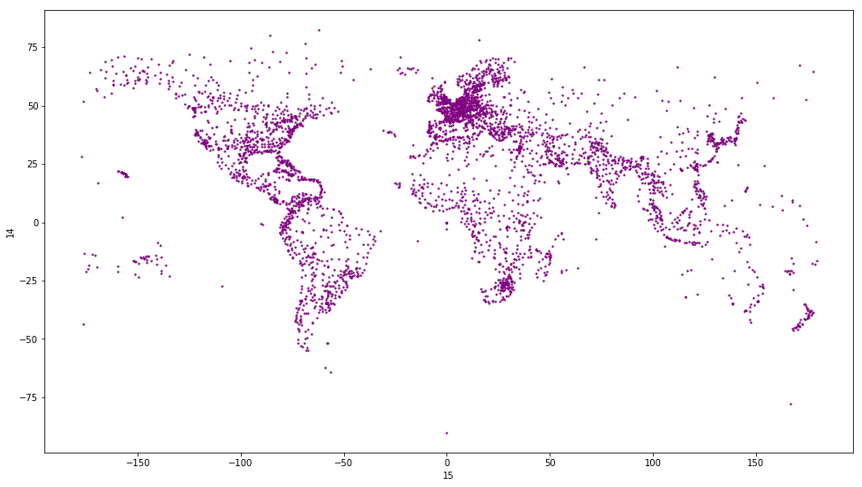

```python
lat_long.plot.scatter(x=15, y=14, s=2, c='purple', figsize=(16, 9))
```

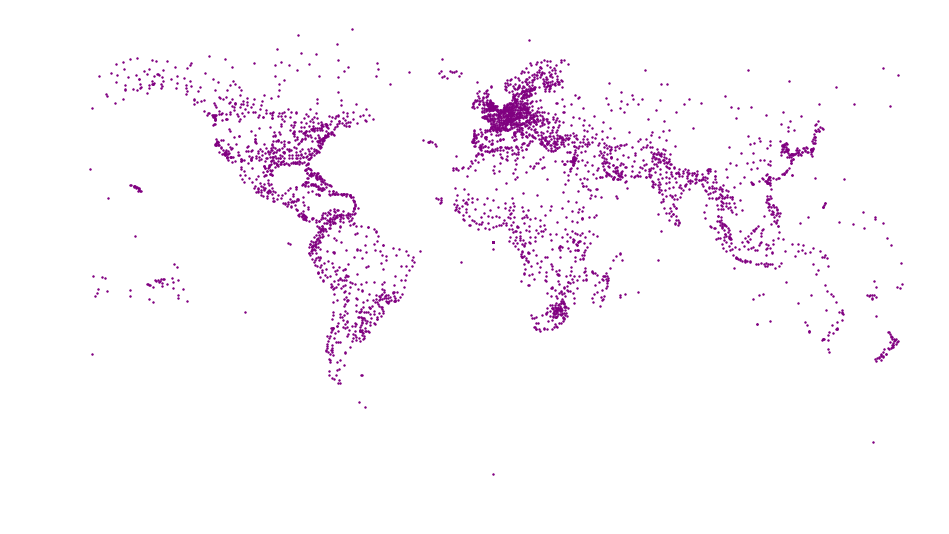

```python
import matplotlib.pyplot as plt
lat_long.plot.scatter(x=15, y=14, s=2, c='purple', figsize=(16, 9))
plt.axis('off')
plt.show()
```

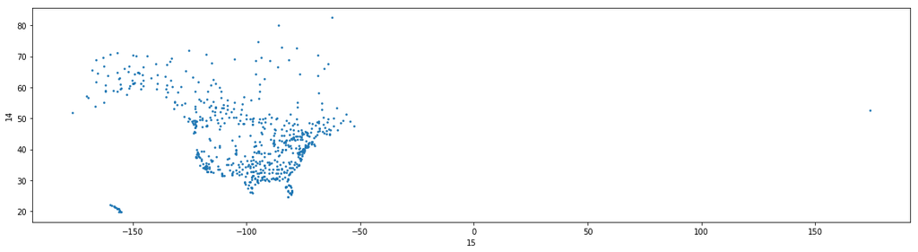

```python
lat_long[(lat_long[4].isin(['CANADA', 'USA'])) &
         (lat_long[14] != 0.0) &
         (lat_long[15] != 0.0)].plot.scatter(x=15, y=14, s=3,  figsize=(20, 5))
```

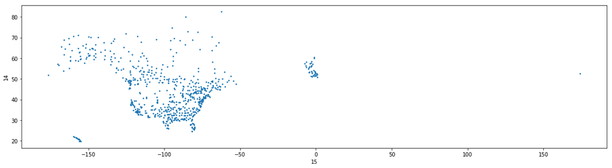

```python
lat_long[(lat_long[4].isin(['CANADA', 'USA', 'UK'])) &
         (lat_long[14] != 0.0) &
         (lat_long[15] != 0.0)].plot.scatter(x=15, y=14, s=3, figsize=(20, 5))
```

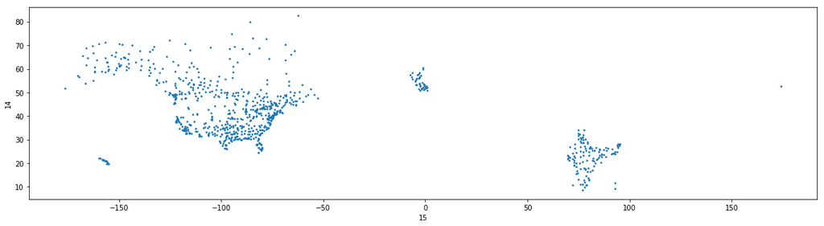

```python
lat_long[(lat_long[4].isin(['CANADA', 'USA', 'UK', 'INDIA'])) &
         (lat_long[14] != 0.0) &
         (lat_long[15] != 0.0)].plot.scatter(x=15, y=14, s=3, figsize=(20, 5))
```

```python
len(flights_in_US)
```

```
457982
```

```python
flights_in_US.head()
```

|  | YEAR | ORIGIN | DEST | UNIQUE_CARRIER_NAME | PASSENGERS |
| --- | --- | --- | --- | --- | --- |
| 0 | 1990 | ABE | ACY | {'US Airways Inc.'} | 73.0 |
| 1 | 1990 | ABE | ATL | {'Eastern Air Lines Inc.'} | 73172.0 |
| 2 | 1990 | ABE | AVL | {'Westair Airlines Inc.'} | 0.0 |
| 3 | 1990 | ABE | AVP | {'Westair Airlines Inc.', 'US Airways Inc.', '... | 8397.0 |
| 4 | 1990 | ABE | BHM | {'Eastern Air Lines Inc.'} | 59.0 |

```python
flights_in_US[(flights_in_US.ORIGIN == 'JFK') &
              (flights_in_US.YEAR == 2015) &
              (flights_in_US.DEST == 'SFO')]
```

|  | YEAR | ORIGIN | DEST | UNIQUE_CARRIER_NAME | PASSENGERS |
| --- | --- | --- | --- | --- | --- |
| 444602 | 2015 | JFK | SFO | {'Delta Air Lines Inc.', 'Virgin America', 'Am... | 1179941.0 |

```python
flights_in_US[(flights_in_US.ORIGIN == 'JFK') &
              (flights_in_US.YEAR == 2015) &
              (flights_in_US.DEST == 'ORD')].UNIQUE_CARRIER_NAME.values[0]
```

```
"{'Delta Air Lines Inc.', 'Endeavor Air Inc.', 'Qantas Airways Ltd.', 'American Airlines Inc.', 'Atlas Air Inc.', 'Cathay Pacific Airways Ltd.', 'GoJet Airlines LLC d/b/a United Express', 'Asiana Airlines Inc.', 'Shuttle America Corp.', 'JetBlue Airways', 'United Air Lines Inc.', 'Lufthansa German A…
```

### What about a network picture of the flights?

```python
import networkx as nx
```

```python
flight_graph = nx.DiGraph()
```

```python
pos_dict = {}
for row in lat_long[lat_long[4] == 'USA'].iterrows():
    airport_code = row[1][1]
    flight_graph.add_node(airport_code)
    pos_dict[airport_code] = (row[1][15], row[1][14])
```

```python
source_airport = 'SFO'
destinations = flights_in_US[(flights_in_US.ORIGIN == source_airport) &
              (flights_in_US.YEAR == 2015)].DEST.unique()
```

```python
for destination in destinations:
    if destination in pos_dict:
        flight_graph.add_edge(source_airport, destination)
```

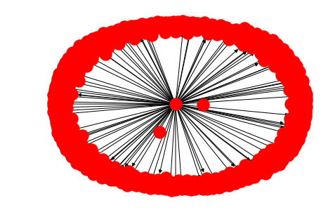

```python
nx.draw(flight_graph)
```

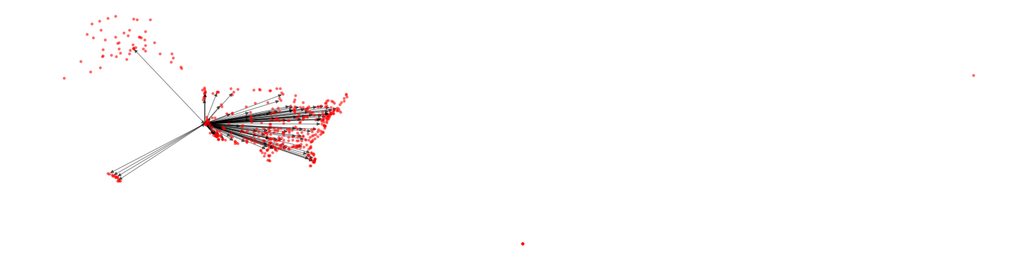

```python
plt.figure(figsize=(20, 5))
nx.draw(flight_graph, pos=pos_dict, node_size=10, alpha=0.5)
```

### Top travel destinations?

```python
flights_in_US[flights_in_US.YEAR == 1990].PASSENGERS.idxmax()
```

```
3917
```

```python
flights_in_US.iloc[3917]
```

```
YEAR                                                                1990
ORIGIN                                                               LAX
DEST                                                                 HNL
UNIQUE_CARRIER_NAME    {'Heavylift Cargo Airlines Lt', 'Hawaiian Airl...
PASSENGERS                                                   1.82716e+06
Name: 3917, dtype: object
```

```python
flights_in_US[(flights_in_US.ORIGIN == 'LAX') & (flights_in_US.DEST == 'HNL')]
```

|  | YEAR | ORIGIN | DEST | UNIQUE_CARRIER_NAME | PASSENGERS |
| --- | --- | --- | --- | --- | --- |
| 3917 | 1990 | LAX | HNL | {'Heavylift Cargo Airlines Lt', 'Hawaiian Airl... | 1827164.0 |
| 11810 | 1991 | LAX | HNL | {'Hawaiian Airlines Inc.', 'Delta Air Lines In... | 1828453.0 |
| 19632 | 1992 | LAX | HNL | {'America West Airlines Inc.', 'Hawaiian Airli... | 1732270.0 |
| 27410 | 1993 | LAX | HNL | {'Express One International Inc.', 'Hawaiian A... | 1826148.0 |
| 35235 | 1994 | LAX | HNL | {'Express One International Inc.', 'Hawaiian A... | 1696143.0 |
| 43472 | 1995 | LAX | HNL | {'Hawaiian Airlines Inc.', 'Continental Micron... | 1715915.0 |
| 52495 | 1996 | LAX | HNL | {'Hawaiian Airlines Inc.', 'Delta Air Lines In... | 1664672.0 |
| 61730 | 1997 | LAX | HNL | {'Hawaiian Airlines Inc.', 'Delta Air Lines In... | 1597944.0 |
| 70739 | 1998 | LAX | HNL | {'Hawaiian Airlines Inc.', 'Delta Air Lines In... | 1456153.0 |
| 80086 | 1999 | LAX | HNL | {'Heavylift Cargo Airlines Lt', 'Hawaiian Airl... | 1409678.0 |
| 90435 | 2000 | LAX | HNL | {'Hawaiian Airlines Inc.', 'Delta Air Lines In... | 1462597.0 |
| 101838 | 2001 | LAX | HNL | {'Hawaiian Airlines Inc.', 'Delta Air Lines In... | 1361228.0 |
| 118082 | 2002 | LAX | HNL | {'Federal Express Corporation', 'Hawaiian Airl... | 1395797.0 |
| 140159 | 2003 | LAX | HNL | {'Federal Express Corporation', 'Hawaiian Airl... | 1226091.0 |
| 165434 | 2004 | LAX | HNL | {'Federal Express Corporation', 'Hawaiian Airl... | 1240272.0 |
| 191679 | 2005 | LAX | HNL | {'Federal Express Corporation', 'Hawaiian Airl... | 1271700.0 |
| 217069 | 2006 | LAX | HNL | {'Federal Express Corporation', 'Hawaiian Airl... | 1107015.0 |
| 243328 | 2007 | LAX | HNL | {'Federal Express Corporation', 'Hawaiian Airl... | 1142267.0 |
| 270343 | 2008 | LAX | HNL | {'Federal Express Corporation', 'Hawaiian Airl... | 1026419.0 |
| 296041 | 2009 | LAX | HNL | {'Federal Express Corporation', 'Hawaiian Airl... | 976228.0 |
| 321265 | 2010 | LAX | HNL | {'Federal Express Corporation', 'Hawaiian Airl... | 1009671.0 |
| 346789 | 2011 | LAX | HNL | {'Federal Express Corporation', 'Hawaiian Airl... | 1080653.0 |
| 371644 | 2012 | LAX | HNL | {'Federal Express Corporation', 'Hawaiian Airl... | 1050588.0 |
| 395899 | 2013 | LAX | HNL | {'Federal Express Corporation', 'Hawaiian Airl... | 1062594.0 |
| 420469 | 2014 | LAX | HNL | {'Federal Express Corporation', 'Hawaiian Airl... | 1123975.0 |
| 445889 | 2015 | LAX | HNL | {'Federal Express Corporation', 'Hawaiian Airl... | 1115732.0 |

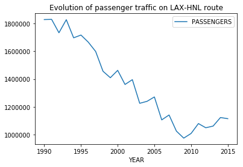

```python
flights_in_US[(flights_in_US.ORIGIN == 'LAX') & (flights_in_US.DEST == 'HNL')].plot(
    x='YEAR', y='PASSENGERS', title='Evolution of passenger traffic on LAX-HNL route')
```

```python
flights_in_US[flights_in_US.YEAR == 2015].PASSENGERS.idxmax()
```

```
445978
```

```python
flights_in_US.iloc[445978]
```

```
YEAR                                                                2015
ORIGIN                                                               LAX
DEST                                                                 SFO
UNIQUE_CARRIER_NAME    {'Hawaiian Airlines Inc.', 'Delta Air Lines In...
PASSENGERS                                                   1.86907e+06
Name: 445978, dtype: object
```

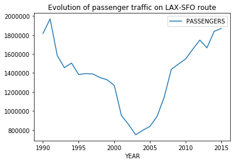

```python
flights_in_US[(flights_in_US.ORIGIN == 'LAX') & (flights_in_US.DEST == 'SFO')].plot(
    x='YEAR', y='PASSENGERS', title='Evolution of passenger traffic on LAX-SFO route')
```

### What about the total number of passengers?

```python
flights_in_US.groupby(['YEAR']).sum()
```

| YEAR | PASSENGERS |
| --- | --- |
| 1990 | 448862173.0 |
| 1991 | 434938145.0 |
| 1992 | 454342213.0 |
| 1993 | 464431692.0 |
| 1994 | 505298026.0 |
| 1995 | 519495497.0 |
| 1996 | 548286560.0 |
| 1997 | 564392466.0 |
| 1998 | 575354633.0 |
| 1999 | 597714868.0 |
| 2000 | 623049036.0 |
| 2001 | 580446827.0 |
| 2002 | 571912627.0 |
| 2003 | 604060205.0 |
| 2004 | 651179228.0 |
| 2005 | 676692491.0 |
| 2006 | 676812884.0 |
| 2007 | 698348181.0 |
| 2008 | 669749629.0 |
| 2009 | 634897818.0 |
| 2010 | 646481572.0 |
| 2011 | 656320870.0 |
| 2012 | 657645308.0 |
| 2013 | 660057640.0 |
| 2014 | 676358409.0 |
| 2015 | 707749086.0 |

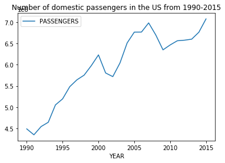

```python
flights_in_US.groupby(['YEAR']).sum().plot(title='Number of domestic passengers in the US from 1990-2015')
```

#### Monthly dataset exhibits seasonality as expected.

[figure not shown]

### Exercise

Plot the number of passengers from New York airports (JFK, EWR, LGA) to SFO, LAX, ORD from 1990-2015. (3 separate plots)

HINTS:

- to check if value belongs to a list in pandas, use `.isin()` function
- use `groupby` for summing the number of passengers.

(8 mins)

```python
list_of_new_york_airports = ['JFK', 'EWR', 'LGA']
```

```python
# %load sols/exercise3.py
```

### A Shoutout to Seaborn

A great library for statistical visualisations.

In depth tutorial and documentation: https://seaborn.pydata.org/tutorial.html

```python
import seaborn as sns
sns.set(style="darkgrid")
```

```python
tips = sns.load_dataset("tips")
```

```python
tips.head()
```

|  | total_bill | tip | sex | smoker | day | time | size |
| --- | --- | --- | --- | --- | --- | --- | --- |
| 0 | 16.99 | 1.01 | Female | No | Sun | Dinner | 2 |
| 1 | 10.34 | 1.66 | Male | No | Sun | Dinner | 3 |
| 2 | 21.01 | 3.50 | Male | No | Sun | Dinner | 3 |
| 3 | 23.68 | 3.31 | Male | No | Sun | Dinner | 2 |
| 4 | 24.59 | 3.61 | Female | No | Sun | Dinner | 4 |

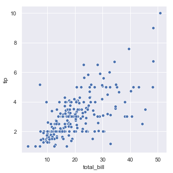

```python
sns.relplot(x="total_bill", y="tip", data=tips)
```

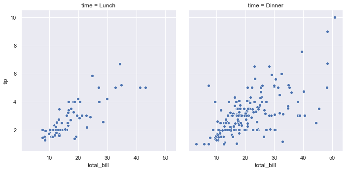

```python
sns.relplot(x="total_bill", y="tip", data=tips, col='time')
```

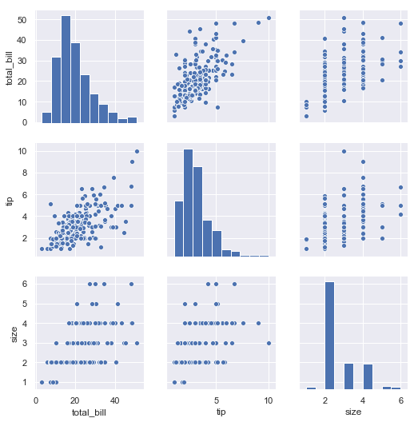

```python
sns.pairplot(tips)
```

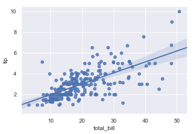

```python
sns.regplot(x="total_bill", y="tip", data=tips)
```

### Let's level up, and look at the NYC yellow taxi tips dataset

8.7 million trips just in June 2018

```python
tips = pd.read_csv('nyc_taxi.csv', index_col=0)
```

```python
tips.head()
```

|  | tpep_pickup_datetime | tpep_dropoff_datetime | trip_distance | fare_amount | tip_amount |
| --- | --- | --- | --- | --- | --- |
| 1 | 00:04:18 | 00:09:18 | 1.0 | 5.5 | 1.35 |
| 5 | 00:09:00 | 00:24:01 | 2.0 | 11.5 | 2.55 |
| 6 | 00:02:33 | 00:13:01 | 1.5 | 8.5 | 1.95 |
| 7 | 00:13:23 | 00:16:52 | 0.7 | 5.0 | 1.85 |
| 11 | 00:39:42 | 00:57:23 | 3.5 | 13.5 | 2.95 |

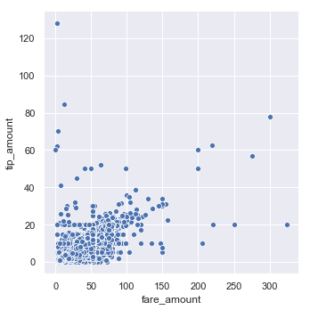

```python
sns.relplot(x="fare_amount", y="tip_amount", data=tips)
```

```python
off_hour = list()
for row in tips.iterrows():
    if (row[1]['tpep_pickup_datetime'] > '06:00:00') & ((row[1]['tpep_pickup_datetime'] < '23:59:59')):
        off_hour.append(0)
    else:
        off_hour.append(1)
```

```python
tips['off_hour'] = off_hour
```

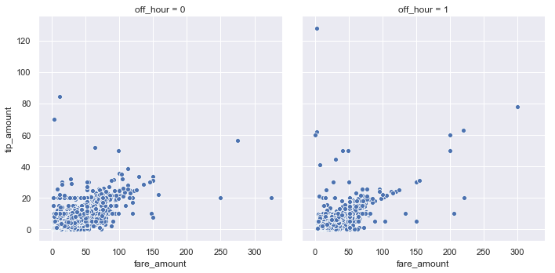

```python
sns.relplot(x="fare_amount", y="tip_amount", data=tips, col='off_hour')
```